# SG_01_FUNDRAISER_ADDR_STATE

Fundraiser state · Code report

## Overview

**Description**

Province or state

**Table**

`SG-P01-T01-FUNDRAISERS-INFO` (many)

**Location code**

`SCHED-G-PART-01-LINE-02B-COL-i`

**Family**

`SCHED-G-PART-01-LINE-02B-COL-i` · siblings: SG_01_FUNDRAISER_ADDR_CITY, SG_01_FUNDRAISER_ADDR_CNTR, SG_01_FUNDRAISER_ADDR_L1, SG_01_FUNDRAISER_ADDR_L2, SG_01_FUNDRAISER_ADDR_ZIP, SG_01_FUNDRAISER_NAME_INDIV

**Data type**

**Scope**

PZ

**Status**

unreviewed

6

xpaths mapped (6 observed)

68,476

filings with a value

2010–2024

tax years observed

4

open flags (1 errors)

## Flags

| Severity | Flag | Xpath | Detail |
| --- | --- | --- | --- |
| ⚠ error | `COLLISION` | IRS990ScheduleG/FundraiserActivityInfoGrp/ForeignAddress/ProvinceOrStateNm | 367 filings contain 2+ of its xpaths; most common set: /Return/ReturnData/IRS990ScheduleG/FundraiserActivityInfoGrp/ForeignAddress/ProvinceOrStateNm ; /Return/ReturnData/IRS990ScheduleG/FundraiserActi… |
| ⓘ info | `MANY_NOT_REPEATING` | IRS990ScheduleG/FundraiserActivityInfoGrp/USAddress/StateAbbreviationCd | many-to-one table, but 72% of values sit in no repeating element |
| ⓘ info | `MANY_NOT_REPEATING` | IRS990ScheduleG/FundraiserActivityInformation/AddressUS/State | many-to-one table, but 71% of values sit in no repeating element |
| ⓘ info | `MANY_NOT_REPEATING` | IRS990ScheduleG/FundraiserActivityInfoGrp/USAddress/State | many-to-one table, but 71% of values sit in no repeating element |

## Xpaths

All mapped xpaths (under /Return/ReturnData or /Return/ReturnHeader), oldest first. Charts label each series by its xpath.

| Xpath | Form | Chart label | First year | Last year | Versions | Filings | Repeats in |
| --- | --- | --- | --- | --- | --- | --- | --- |
| IRS990ScheduleG/FundraiserActivityInformation/AddressUS/State | Sched G | …90ScheduleG/FundraiserActivityInformation/AddressUS/State | 2010 | 2012 | 12 | 9,547 | 28.5% |
| IRS990ScheduleG/FundraiserActivityInformation/AddressForeign/ProvinceOrState | Sched G | …draiserActivityInformation/AddressForeign/ProvinceOrState | 2010 | 2012 | 9 | 77 | 18.2% |
| IRS990ScheduleG/FundraiserActivityInfoGrp/USAddress/State | Sched G | same | 2013 | 2013 | 3 | 4,040 | 27.6% |
| IRS990ScheduleG/FundraiserActivityInfoGrp/ForeignAddress/ProvinceOrState | Sched G | …/FundraiserActivityInfoGrp/ForeignAddress/ProvinceOrState | 2013 | 2013 | 3 | 28 | 10.7% |
| IRS990ScheduleG/FundraiserActivityInfoGrp/USAddress/StateAbbreviationCd | Sched G | …G/FundraiserActivityInfoGrp/USAddress/StateAbbreviationCd | 2014 | 2024 | 34 | 54,332 | 27.1% |
| IRS990ScheduleG/FundraiserActivityInfoGrp/ForeignAddress/ProvinceOrStateNm | Sched G | …undraiserActivityInfoGrp/ForeignAddress/ProvinceOrStateNm | 2014 | 2024 | 31 | 452 | 15.3% |

## Coverage

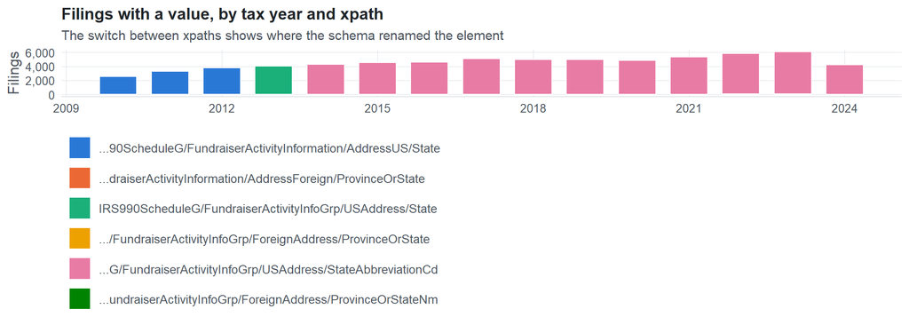

**Table view**

Table view: filings by tax year and series

| Tax year | …90ScheduleG/FundraiserActivityInformation/AddressUS/State | …draiserActivityInformation/AddressForeign/ProvinceOrState | IRS990ScheduleG/FundraiserActivityInfoGrp/USAddress/State | …/FundraiserActivityInfoGrp/ForeignAddress/ProvinceOrState | …G/FundraiserActivityInfoGrp/USAddress/StateAbbreviationCd | …undraiserActivityInfoGrp/ForeignAddress/ProvinceOrStateNm |
| --- | --- | --- | --- | --- | --- | --- |
| 2010 | 2,546 | 24 | 0 | 0 | 0 | 0 |
| 2011 | 3,261 | 27 | 0 | 0 | 0 | 0 |
| 2012 | 3,740 | 26 | 0 | 0 | 0 | 0 |
| 2013 | 0 | 0 | 4,040 | 28 | 0 | 0 |
| 2014 | 0 | 0 | 0 | 0 | 4,268 | 27 |
| 2015 | 0 | 0 | 0 | 0 | 4,502 | 30 |
| 2016 | 0 | 0 | 0 | 0 | 4,586 | 37 |
| 2017 | 0 | 0 | 0 | 0 | 5,043 | 31 |
| 2018 | 0 | 0 | 0 | 0 | 4,932 | 40 |
| 2019 | 0 | 0 | 0 | 0 | 4,909 | 40 |
| 2020 | 0 | 0 | 0 | 0 | 4,794 | 37 |
| 2021 | 0 | 0 | 0 | 0 | 5,278 | 47 |
| 2022 | 0 | 0 | 0 | 0 | 5,772 | 65 |
| 2023 | 0 | 0 | 0 | 0 | 6,040 | 62 |
| 2024 | 0 | 0 | 0 | 0 | 4,208 | 36 |

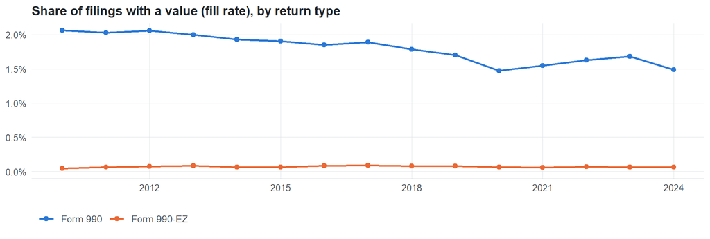

**Table view**

Table view: fill rate

| Tax year | Return type | Filings | All filings | Fill rate |
| --- | --- | --- | --- | --- |
| 2010 | Form 990 | 2,540 | 123,025 | 2.06% |
| 2010 | Form 990-EZ | 30 | 63,326 | 0.05% |
| 2011 | Form 990 | 3,233 | 159,504 | 2.03% |
| 2011 | Form 990-EZ | 55 | 82,048 | 0.07% |
| 2012 | Form 990 | 3,695 | 179,688 | 2.06% |
| 2012 | Form 990-EZ | 71 | 93,750 | 0.08% |
| 2013 | Form 990 | 3,979 | 198,855 | 2.00% |
| 2013 | Form 990-EZ | 89 | 104,375 | 0.09% |
| 2014 | Form 990 | 4,218 | 218,619 | 1.93% |
| 2014 | Form 990-EZ | 77 | 116,417 | 0.07% |
| 2015 | Form 990 | 4,451 | 233,519 | 1.91% |
| 2015 | Form 990-EZ | 81 | 124,894 | 0.06% |
| 2016 | Form 990 | 4,511 | 243,903 | 1.85% |
| 2016 | Form 990-EZ | 112 | 130,484 | 0.09% |
| 2017 | Form 990 | 4,947 | 261,612 | 1.89% |
| 2017 | Form 990-EZ | 127 | 139,144 | 0.09% |
| 2018 | Form 990 | 4,851 | 271,442 | 1.79% |
| 2018 | Form 990-EZ | 121 | 149,384 | 0.08% |
| 2019 | Form 990 | 4,830 | 283,694 | 1.70% |
| 2019 | Form 990-EZ | 119 | 152,622 | 0.08% |
| 2020 | Form 990 | 4,720 | 320,342 | 1.47% |
| 2020 | Form 990-EZ | 111 | 169,864 | 0.07% |
| 2021 | Form 990 | 5,200 | 336,480 | 1.55% |
| 2021 | Form 990-EZ | 125 | 202,724 | 0.06% |
| 2022 | Form 990 | 5,688 | 349,055 | 1.63% |
| 2022 | Form 990-EZ | 149 | 206,130 | 0.07% |
| 2023 | Form 990 | 5,972 | 354,768 | 1.68% |
| 2023 | Form 990-EZ | 130 | 206,379 | 0.06% |
| 2024 | Form 990 | 4,128 | 277,298 | 1.49% |
| 2024 | Form 990-EZ | 116 | 178,867 | 0.06% |

## Repeating groups

Table cardinality in the concordance: **many**. 6 of 6 observed xpaths repeat within a filing.

Repeating element each xpath was observed in (from the raw indexed xpath)

| Xpath | Repeating element | Filings (summed over years) |
| --- | --- | --- |
| IRS990ScheduleG/FundraiserActivityInformation/AddressForeign/ProvinceOrState | (none) | 17 |
| IRS990ScheduleG/FundraiserActivityInformation/AddressForeign/ProvinceOrState | IRS990ScheduleG/FundraiserActivityInformation | 60 |
| IRS990ScheduleG/FundraiserActivityInformation/AddressUS/State | (none) | 6758 |
| IRS990ScheduleG/FundraiserActivityInformation/AddressUS/State | IRS990ScheduleG/FundraiserActivityInformation | 2789 |
| IRS990ScheduleG/FundraiserActivityInfoGrp/ForeignAddress/ProvinceOrState | (none) | 12 |
| IRS990ScheduleG/FundraiserActivityInfoGrp/ForeignAddress/ProvinceOrState | IRS990ScheduleG/FundraiserActivityInfoGrp | 16 |
| IRS990ScheduleG/FundraiserActivityInfoGrp/USAddress/State | (none) | 2886 |
| IRS990ScheduleG/FundraiserActivityInfoGrp/USAddress/State | IRS990ScheduleG/FundraiserActivityInfoGrp | 1154 |
| IRS990ScheduleG/FundraiserActivityInfoGrp/ForeignAddress/ProvinceOrStateNm | (none) | 126 |
| IRS990ScheduleG/FundraiserActivityInfoGrp/ForeignAddress/ProvinceOrStateNm | IRS990ScheduleG/FundraiserActivityInfoGrp | 326 |
| IRS990ScheduleG/FundraiserActivityInfoGrp/USAddress/StateAbbreviationCd | (none) | 39016 |
| IRS990ScheduleG/FundraiserActivityInfoGrp/USAddress/StateAbbreviationCd | IRS990ScheduleG/FundraiserActivityInfoGrp | 15316 |

## Values

| Result | Check | Detail |
| --- | --- | --- |
| ✓ pass | Small code list | up to 62 distinct values per xpath and year |
| ✓ pass | Codes share one format | 99% have the shape AA |
| ✓ pass | Consistent letter case | 0.0% of values are lower case |

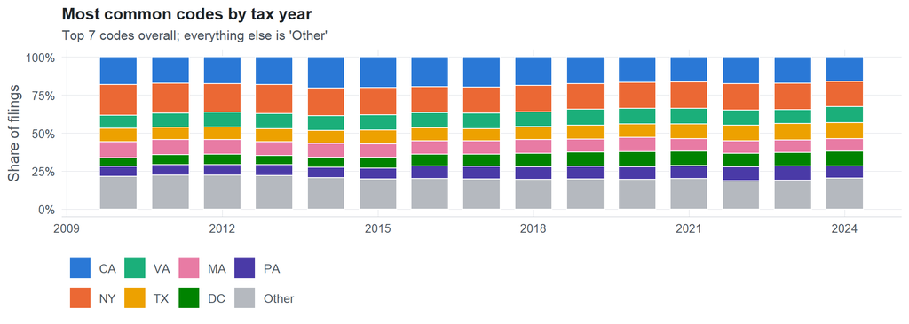

**Table view**

Table view: filings by code and tax year

| tax_year | CA | NY | VA | TX | MA | DC | PA | Other |
| --- | --- | --- | --- | --- | --- | --- | --- | --- |
| 2010 | 352 | 391 | 169 | 170 | 205 | 111 | 125 | 420 |
| 2011 | 437 | 488 | 236 | 202 | 255 | 162 | 168 | 567 |
| 2012 | 503 | 532 | 282 | 235 | 272 | 197 | 194 | 642 |
| 2013 | 563 | 588 | 315 | 257 | 287 | 188 | 220 | 684 |
| 2014 | 680 | 600 | 325 | 287 | 298 | 220 | 227 | 689 |
| 2015 | 705 | 618 | 355 | 311 | 311 | 252 | 249 | 690 |
| 2016 | 701 | 611 | 360 | 301 | 319 | 271 | 300 | 721 |
| 2017 | 779 | 660 | 395 | 319 | 342 | 309 | 320 | 778 |
| 2018 | 704 | 666 | 366 | 325 | 340 | 332 | 315 | 741 |
| 2019 | 668 | 634 | 391 | 348 | 321 | 352 | 316 | 750 |
| 2020 | 628 | 632 | 380 | 335 | 343 | 370 | 309 | 734 |
| 2021 | 658 | 703 | 404 | 393 | 337 | 369 | 344 | 813 |
| 2022 | 789 | 780 | 450 | 460 | 374 | 404 | 408 | 842 |
| 2023 | 801 | 800 | 424 | 495 | 387 | 412 | 430 | 879 |
| 2024 | 491 | 509 | 326 | 321 | 253 | 291 | 244 | 630 |

Code frequencies (all xpaths, all years)

| Code | Filings | Share |
| --- | --- | --- |
| CA | 9,459 | 18.1% |
| NY | 9,212 | 17.6% |
| VA | 5,178 | 9.9% |
| TX | 4,759 | 9.1% |
| MA | 4,644 | 8.9% |
| DC | 4,240 | 8.1% |
| PA | 4,169 | 8.0% |
| IL | 3,856 | 7.4% |
| GA | 2,653 | 5.1% |
| MN | 1,747 | 3.3% |
| NJ | 823 | 1.6% |
| MD | 610 | 1.2% |
| IA | 452 | 0.9% |
| ONTARIO | 162 | 0.3% |
| Ontario | 93 | 0.2% |
| ON | 26 | 0.0% |
| BC | 24 | 0.0% |
| British Columbia | 20 | 0.0% |
| Quebec | 14 | 0.0% |
| NOVA SCOTIA | 13 | 0.0% |
| BRITISH COLUMBIA | 7 | 0.0% |
| QUEBEC | 6 | 0.0% |
| ISRAEL | 6 | 0.0% |
| LONDON | 6 | 0.0% |
| AGUADILLA | 5 | 0.0% |
| CANADA | 4 | 0.0% |
| GENEVA | 2 | 0.0% |
| MB | 2 | 0.0% |
| Manitoba | 2 | 0.0% |
| Alberta | 2 | 0.0% |

First rows shown.

## Examples

| Tax year | Return | Xpath | Organization | Value | Source |
| --- | --- | --- | --- | --- | --- |
| 2024 | 990 | IRS990ScheduleG/FundraiserActivityInfoGrp/ForeignAddress/ProvinceOrStateNm | Women for Afghan Women Inc | Singravenstraar | [XML](https://gt990datalake-rawdata.s3.amazonaws.com/EfileData/XmlFiles/202543079349301299_public.xml) |
| 2024 | 990 | IRS990ScheduleG/FundraiserActivityInfoGrp/USAddress/StateAbbreviationCd | THE CLEVELAND CLINIC FOUNDATION | CA | [XML](https://gt990datalake-rawdata.s3.amazonaws.com/EfileData/XmlFiles/202513189349302136_public.xml) |
| 2023 | 990 | IRS990ScheduleG/FundraiserActivityInfoGrp/ForeignAddress/ProvinceOrStateNm | INTERNATIONAL CITYCOUNTY MANAGEMENT | QUEBEC | [XML](https://gt990datalake-rawdata.s3.amazonaws.com/EfileData/XmlFiles/202531349349305838_public.xml) |
| 2023 | 990 | IRS990ScheduleG/FundraiserActivityInfoGrp/USAddress/StateAbbreviationCd | LOUISVILLE PROFESSIONAL FIREFIGHTERS | TN | [XML](https://gt990datalake-rawdata.s3.amazonaws.com/EfileData/XmlFiles/202423209349320882_public.xml) |
| 2022 | 990 | IRS990ScheduleG/FundraiserActivityInfoGrp/ForeignAddress/ProvinceOrStateNm | UNSTOPPABLE FOUNDATION | ON L3X1C3 | [XML](https://gt990datalake-rawdata.s3.amazonaws.com/EfileData/XmlFiles/202302099349301760_public.xml) |
| 2022 | 990 | IRS990ScheduleG/FundraiserActivityInfoGrp/USAddress/StateAbbreviationCd | PHOENIX COMMUNITY ALLIANCE | AZ | [XML](https://gt990datalake-rawdata.s3.amazonaws.com/EfileData/XmlFiles/202303199349316930_public.xml) |
| 2021 | 990 | IRS990ScheduleG/FundraiserActivityInfoGrp/ForeignAddress/ProvinceOrStateNm | THE HAWN FOUNDATION | BRITISH COLUMBIA | [XML](https://gt990datalake-rawdata.s3.amazonaws.com/EfileData/XmlFiles/202223189349319867_public.xml) |
| 2021 | 990 | IRS990ScheduleG/FundraiserActivityInfoGrp/USAddress/StateAbbreviationCd | NATIONAL ABORTION FEDERATION | DC | [XML](https://gt990datalake-rawdata.s3.amazonaws.com/EfileData/XmlFiles/202222909349301502_public.xml) |
| 2020 | 990 | IRS990ScheduleG/FundraiserActivityInfoGrp/ForeignAddress/ProvinceOrStateNm | CHARITIES AID FOUNDATION AMERICA | ONTARIO | [XML](https://gt990datalake-rawdata.s3.amazonaws.com/EfileData/XmlFiles/202220739349300922_public.xml) |
| 2020 | 990 | IRS990ScheduleG/FundraiserActivityInfoGrp/USAddress/StateAbbreviationCd | Nashville Symphony Association | WI | [XML](https://gt990datalake-rawdata.s3.amazonaws.com/EfileData/XmlFiles/202231649349300423_public.xml) |
| 2019 | 990 | IRS990ScheduleG/FundraiserActivityInfoGrp/ForeignAddress/ProvinceOrStateNm | Food For The Hungry Inc | British Columbia | [XML](https://gt990datalake-rawdata.s3.amazonaws.com/EfileData/XmlFiles/202111589349300421_public.xml) |
| 2019 | 990 | IRS990ScheduleG/FundraiserActivityInfoGrp/USAddress/StateAbbreviationCd | Santa Clara Police Association | CA | [XML](https://gt990datalake-rawdata.s3.amazonaws.com/EfileData/XmlFiles/202120479349300222_public.xml) |

## Reviewer checklist

- The definition matches the form line and instructions for every xpath’s schema years.
- Every xpath pooled here measures the same thing on the 990 and 990-EZ (close enough for analysis).
- The coverage chart has no unexplained gaps or jumps between tax years.
- Each open flag is fixed, or accepted with a note in validation_log.csv.
- Every code is valid for the list the form uses (state, country, valuation method, …).
- The code list and its meaning did not change across schema versions.
- Codes are stored as text, so values like leading zeros are preserved.

Record the review as a row in `inst/extdata/src/validation_log.csv` (variable_name, reviewer, date, status, note). Evidence built 2026-09-23 17:09:04 MST from the ef2 DuckDB builds (tax years 2009–2024).